# Lab09Airbnb

Bao Linh Hoang

2023-12-01

# Lab 09 Airbnb

## Introduction

This report explores the Columbus Airbnb dataset, focusing on factors influencing the pricing of rental units in Columbus, Ohio. The dataset encompasses various variables related to property characteristics, geographic locations, and time considerations. Key variables include ‘accommodates,’ ‘number_of_reviews,’ ‘availability_365,’ ‘minimum_nights,’ ‘maximum_nights,’ and ‘price.’ The primary research questions revolve around understanding the critical factors affecting rental prices and building predictive models for pricing. Ethical considerations in this analysis include data privacy, as the dataset contains information about hosts and guests. Potential stakeholders include renters, property owners, and Airbnb as a platform. Repercussions of the analysis may impact social aspects, statistical interpretations, and communication ethics, emphasizing the need for responsible data handling and reporting.

## Data Exploration

In the process of exploring the Columbus Airbnb dataset, I focused on the key variables: price, property_type, and room_type.In the this analysis, I am delving into the relationships between these variables and further explore their impact on rental prices. The observed patterns suggest potential correlations between room types, property locations, and pricing, which can be essential for building predictive models and making informed decisions about optimal Airbnb offerings in Columbus.

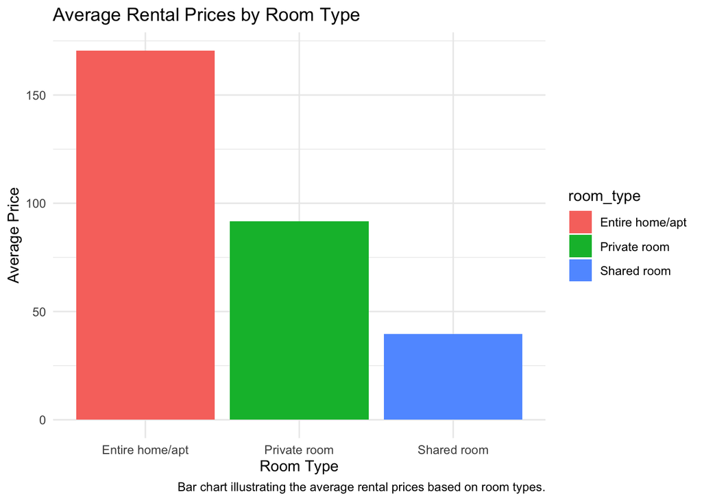

```r
cbus <- cbus %>%
  mutate(price = as.numeric(str_remove_all(price, "[$,]")))
cbus %>%
  group_by(room_type) %>%
  summarise(avg_price = mean(price, na.rm = TRUE)) %>%
  ggplot(aes(x = room_type, y = avg_price, fill = room_type)) +
  geom_bar(stat = "identity", position = "dodge") +
  labs(title = "Average Rental Prices by Room Type",
       x = "Room Type",
       y = "Average Price",
       caption = "Bar chart illustrating the average rental prices based on room types.") +
  theme_minimal()
```

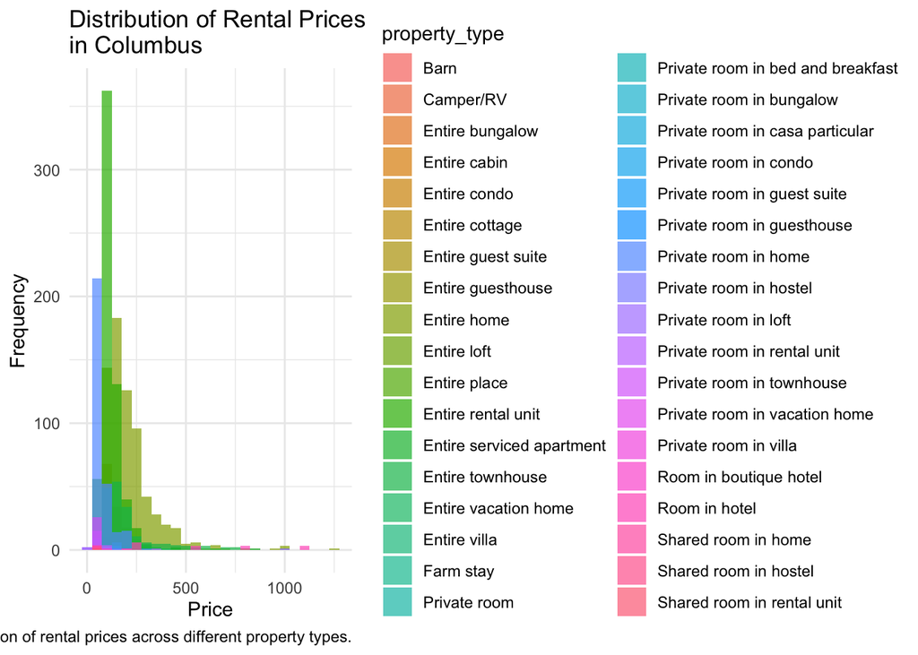

```r
cbus %>%
  ggplot(aes(x = price, fill = property_type)) +
  geom_histogram(binwidth = 50, position = "identity", alpha = 0.7) +
  labs(title = "Distribution of Rental Prices\nin Columbus",
       x = "Price",
       y = "Frequency",
       caption = "Histogram showing the distribution of rental prices across different property types.") +
  theme_minimal()
```

Examining histograms, it became apparent that Columbus tends to have a higher frequency of properties with lower rental prices. Entire places or rental units were more common among the affordable options, while private rooms in villas or vacation homes, representing the higher price range, had a lower frequency.

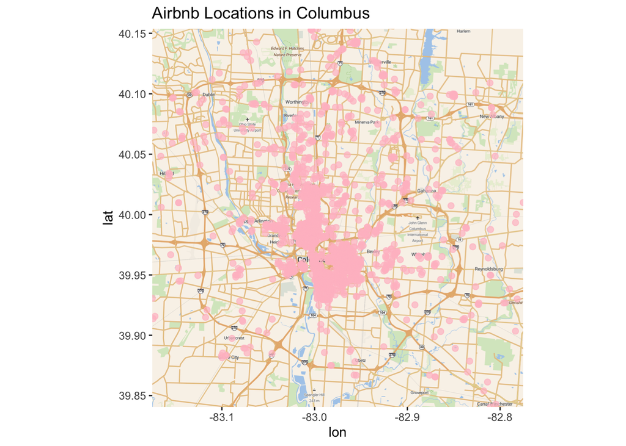

```r
# Load required libraries
library(ggmap)
library(dplyr)

# Set your API key (replace 'YOUR_API_KEY' with your actual API key)
register_google(key = "16c2d6be-62f3-4d73-8abf-8767ed9d2df6")
map_data <- cbus %>%
  dplyr::select(latitude, longitude)

# Get the bounding box for Columbus
columbus_bbox <- c(left = min(map_data$longitude),
                   bottom = min(map_data$latitude),
                   right = max(map_data$longitude),
                   top = max(map_data$latitude))
# Get the map for Columbus
columbus_map <- get_stadiamap(columbus_bbox, zoom = 12, maptype = "outdoors")

ggmap(columbus_map) +
  geom_point(data = map_data, aes(x = longitude, y = latitude), color = "pink", alpha = 0.7, size = 2) +
  labs(title = "Airbnb Locations in Columbus")
```

The map visualization, marked with pink dots representing Airbnb locations, highlighted a concentration around the center and northern part of Columbus. In contrast, areas on the outskirts of the city exhibited fewer Airbnb rental locations. This spatial distribution could inform considerations about property placement and pricing strategies.

## Statistical Analysis

In this section, I aim to answer crucial questions about the factors influencing rental prices in Columbus through regression models.

```r
DataA<-lm(formula = price~number_of_reviews, data=cbus)
summary(DataA)
```

```
##
## Call:
## lm(formula = price ~ number_of_reviews, data = cbus)
##
## Residuals:
##     Min      1Q  Median      3Q     Max
## -143.84  -67.32  -29.51   28.59 1116.04
##
## Coefficients:
##                    Estimate Std. Error t value Pr(>|t|)
## (Intercept)       163.84022    3.11200  52.648  < 2e-16 ***
## number_of_reviews  -0.16728    0.03273  -5.111 3.48e-07 ***
## ---
## Signif. codes:  0 '***' 0.001 '**' 0.01 '*' 0.05 '.' 0.1 ' ' 1
##
## Residual standard error: 123.2 on 2195 degrees of freedom
## Multiple R-squared:  0.01176,    Adjusted R-squared:  0.01131
## F-statistic: 26.12 on 1 and 2195 DF,  p-value: 3.484e-07
```

When we do a regression comparison between the price and number_of_reviews, we can see that both the intercept and the number_of_reviews coefficient have very low p-values (<< 0.05), suggesting that they are statistically significant.The model suggests that the number of reviews has a statistically significant, but relatively small, impact on predicting the price of rental units in Columbus. However, the R-squared value indicates that the model explains only a small portion of the total variability in price, suggesting that other factors not included in the model also influence rental prices. Moreover, a possible linear equation based on the coefficients from the model would be Price=163.84−0.16728×Number of Reviews.

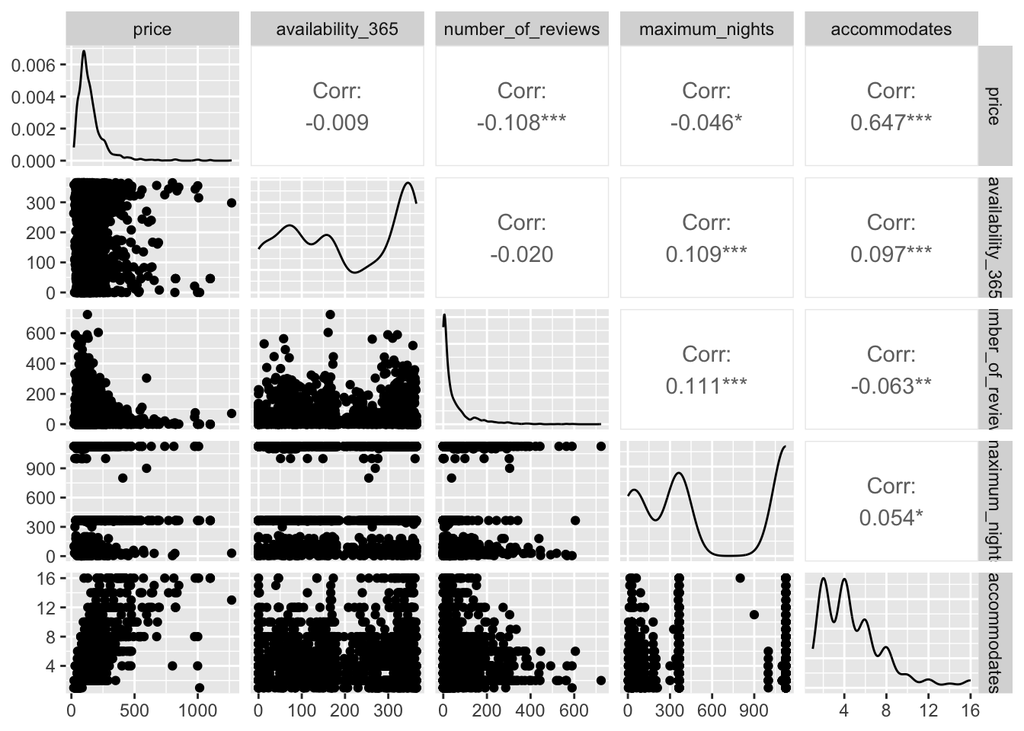

```r
ggpairs(cbus, columns=c('price', 'availability_365', 'number_of_reviews', 'maximum_nights', 'accommodates'))
```

```r
DataB <-lm(formula=price ~ availability_365 + number_of_reviews + accommodates, data = cbus)
summary(DataB)
```

```
##
## Call:
## lm(formula = price ~ availability_365 + number_of_reviews + accommodates,
##     data = cbus)
##
## Residuals:
##     Min      1Q  Median      3Q     Max
## -336.36  -44.30  -13.14   25.41  941.38
##
## Coefficients:
##                   Estimate Std. Error t value Pr(>|t|)
## (Intercept)       47.74200    4.89082   9.762  < 2e-16 ***
## availability_365  -0.07042    0.01558  -4.520 6.51e-06 ***
## number_of_reviews -0.10685    0.02495  -4.283 1.92e-05 ***
## accommodates      25.88212    0.64693  40.007  < 2e-16 ***
## ---
## Signif. codes:  0 '***' 0.001 '**' 0.01 '*' 0.05 '.' 0.1 ' ' 1
##
## Residual standard error: 93.71 on 2193 degrees of freedom
## Multiple R-squared:  0.4288, Adjusted R-squared:  0.428
## F-statistic: 548.7 on 3 and 2193 DF,  p-value: < 2.2e-16
```

```r
confint(DataB,level=0.99)
```

```
##                        0.5 %      99.5 %
## (Intercept)       35.1331039 60.35089409
## availability_365  -0.1105918 -0.03025644
## number_of_reviews -0.1711628 -0.04253638
## accommodates      24.2142759 27.54996093
```

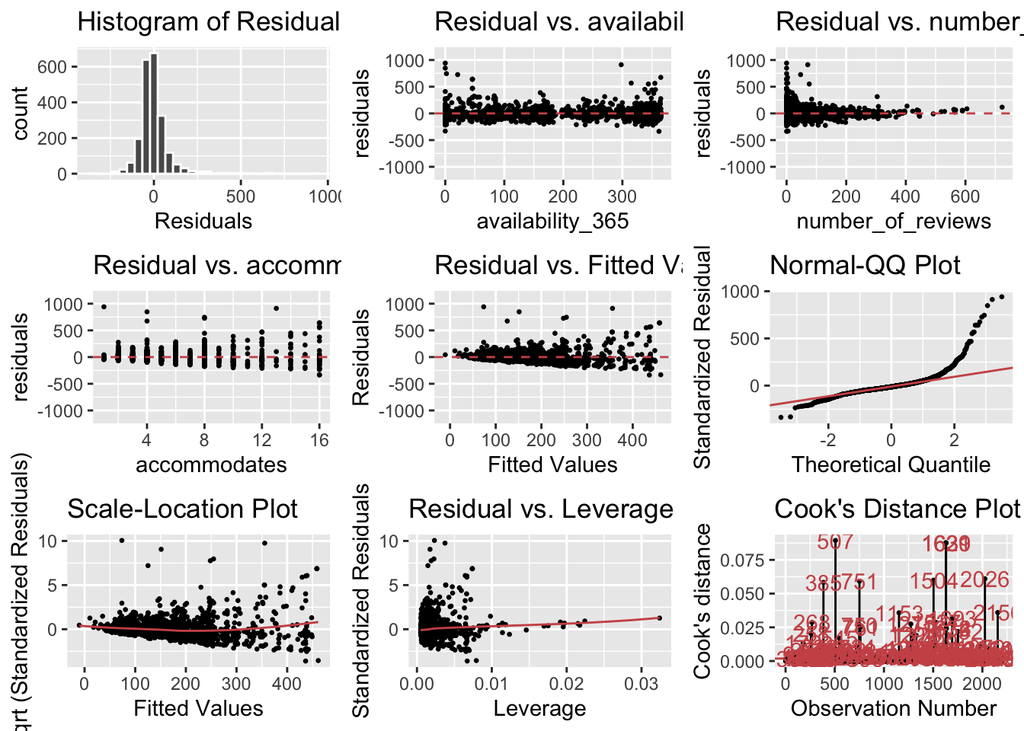

```r
gg_diagnose(DataB)
```

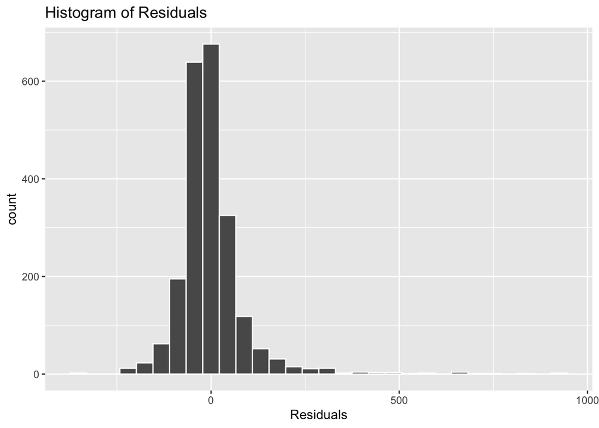

```r
gg_reshist(DataB)
```

From the extensive histogram of residuals and the majority of plots produced by gg_diagnose, it appears that this regression model is probably characterized by a relatively even distribution. Nevertheless, the Normal-QQ plot and Cook’s distance plot suggest a different pattern, possibly influenced by a limited number of residuals situated significantly on the side ranging from 500 to 1000.

## Prediction(s)

```r
lowprice<-data.frame(availability_365=350,number_of_reviews=1,accommodates=1)
predict(DataB,lowprice)
```

```
##        1
## 48.86883
```

```r
medprice<-data.frame(availability_365=100,number_of_reviews=10,accommodates=10)
predict(DataB,medprice)
```

```
##        1
## 298.4523
```

```r
highprice<-data.frame(availability_365=50,number_of_reviews=30,accommodates=30)
predict(DataB,highprice)
```

```
##        1
## 817.4789
```

## Conclusions

For the final Model and take-Home message, I find that the multiple regression model, with an adjusted R-squared of 0.428, demonstrates a moderate level of explanatory power. While the identified variables significantly contribute to predicting rental prices, it’s crucial to acknowledge the model’s limitations. Factors not included in the analysis may also influence pricing, and the model should be viewed as a guide rather than an exhaustive predictor.

The potential pitfalls from this might be firstly unaccounted Variables. The model might not capture all relevant variables affecting rental prices, leading to potential oversights. In addition, Airbnb pricing is influenced by dynamic market conditions, seasonal variations, and external events, which may not be fully captured in the model.

The articles provided shed light on the multifaceted impact of the short-term rental industry on communities. The Northeastern University study challenges common assumptions, revealing a potential link between the prevalence of Airbnbs in Boston and an increase in violent crime, emphasizing the need for legislative adjustments. Meanwhile, the Galveston case illustrates the broader consequences of short-term rentals, from altering the demographic landscape to eroding community bonds and safety nets during storms. These narratives underscore the complex trade-offs involved in the short-term rental boom, prompting a critical examination of the industry’s role in reshaping neighborhoods, with implications for policy and community preservation.